# PSYC800_Unit2

## Overview

Topic Area: Entertainment

Subtopic: Diverse music listening experiences and preferences dataset

The dataset was obtained from Kaggle and contains information collected as part of a research project focused on exploring music listening experiences and preferences among diverse individuals. The data was gathered through focus group interviews and includes details about participants’ familiarity with various popular artists and music genres. The dataset allows for investigating questions regarding the diversity of music listening experiences across factors like gender, skin color, or nationality. It provides insights into the level of familiarity with both classic and modern artists, as well as the popularity of different tracks.

## Wrangling

I found this dataset on Kaggle, downloaded it as a .csv file, and redesigned it. I changed the column names to match them with the R’s principles and fixed all the inaccuracies in the different columns and rows. Then I imported the final .csv file into this quarto document. I further removed the cells with “I prefer not to say” values for Gender and Country variables and the NA values in the Country column using complete.cases().

```r
library(readr)
library(tidyverse)
library(dplyr)
data <- read_csv("Musicdiv.csv")
data <- subset(data, Gender != "I prefer not to say")
data <- subset(data, Country != "I prefer not to say")
data
```

```
# A tibble: 59 × 51
      ID Age      Gender Skin …¹ Country Highe…² fl_mu…³ eng_w…⁴ Music…⁵ elec_…⁶
   <dbl> <chr>    <chr>  <chr>   <chr>   <chr>   <chr>     <dbl>   <dbl>   <dbl>
 1     1 25-34 y… Male   5       South … Master… Yes           4       5       4
 2     2 35-44 y… Female 2       Europe  Doctor… No            5       5       5
 3     3 18-24 y… Male   2       Europe  Master… Yes           5       4       5
 4     4 45-54 y… Male   3       Europe  Doctor… Yes           4       5       5
 5     6 35-44 y… Male   3       South … Master… Yes           1       5       5
 6     8 45-54 y… Female 4       North … Master… No            1       4       5
 7     9 35-44 y… Male   1       Europe  Doctor… No            4       5       4
 8    10 25-34 y… Male   4       South … Bachel… Yes           5       4       5
 9    11 18-24 y… Male   3       Europe  Bachel… No            5       3       5
10    12 25-34 y… Male   I pref… North … High s… No            4       4       3
# … with 49 more rows, 41 more variables: var_music_taste <dbl>,
#   Kraftwerk <chr>, `Daft Punk` <chr>, `Tangerine Dream` <chr>,
#   Underworld <chr>, `The Prodigy` <chr>, `Do you know these? [Goldie]` <chr>,
#   `Do you know these? [Orbital]` <chr>,
#   `Do you know these? [Skrillex]` <chr>,
#   `Do you know these? [Deadmau5]` <chr>,
#   `Do you know these? [Nur Jaber]` <chr>, …
```

```r
library(tibble)
d_clean <- data[complete.cases(data$Country), ]
x <- tibble(d_clean)
```

Next, I wrangled the cleaned dataset to separate the minimum and maximum Age, re-coded the levels of the Highest_degree variable, and converted Gender and Formal music training variables into a factor form.

```r
library(forcats)
 z<-
   x |>
  separate_wider_delim(
    cols = Age,
    delim = "-",
    names = c("minAge", "maxAge"),
    cols_remove = FALSE
  ) |>
   mutate(across(.cols = c(minAge, maxAge), .fns = parse_number)) |>
   mutate(Highest_degree_re = fct_relevel(factor(Highest_degree),
                                          "High School degree or equivalent",
                                          "Bachelors degree (e.g. BA, BS)",
                                          "Masters degree (e.g MA, MS, MEd)",
                                          "Doctorate (e.g. PhD, EdD)"))|>
   mutate(across(c(Gender, fl_music_training), factor))  |>
   print()
```

```
# A tibble: 59 × 54
      ID minAge maxAge Age        Gender Skin …¹ Country Highe…² fl_mu…³ eng_w…⁴
   <dbl>  <dbl>  <dbl> <chr>      <fct>  <chr>   <chr>   <chr>   <fct>     <dbl>
 1     1     25     34 25-34 yea… Male   5       South … Master… Yes           4
 2     2     35     44 35-44 yea… Female 2       Europe  Doctor… No            5
 3     3     18     24 18-24 yea… Male   2       Europe  Master… Yes           5
 4     4     45     54 45-54 yea… Male   3       Europe  Doctor… Yes           4
 5     6     35     44 35-44 yea… Male   3       South … Master… Yes           1
 6     8     45     54 45-54 yea… Female 4       North … Master… No            1
 7     9     35     44 35-44 yea… Male   1       Europe  Doctor… No            4
 8    10     25     34 25-34 yea… Male   4       South … Bachel… Yes           5
 9    11     18     24 18-24 yea… Male   3       Europe  Bachel… No            5
10    12     25     34 25-34 yea… Male   I pref… North … High s… No            4
# … with 49 more rows, 44 more variables: Music_taste_varied <dbl>,
#   elec_music_listeningfreq <dbl>, var_music_taste <dbl>, Kraftwerk <chr>,
#   `Daft Punk` <chr>, `Tangerine Dream` <chr>, Underworld <chr>,
#   `The Prodigy` <chr>, `Do you know these? [Goldie]` <chr>,
#   `Do you know these? [Orbital]` <chr>,
#   `Do you know these? [Skrillex]` <chr>,
#   `Do you know these? [Deadmau5]` <chr>, …
```

*Finally, the variables in the dataset are:*

[ID: participant ID]

minAge: minimum age of participants (lower limit of the age range)

maxAge: maximum age of participants (upper limit of the age range)

eng_with_music: participant’s level of agreement or disagreement with whether they regulary engage in playing, DJing, or producing any kind of music

Muisc_taste_varied: participant’s level of agreement or disagreement with whether they describe their music tastes as varied

elec_music_listeningfreq: how often participants listen to electronic music

var_music_taste: the extent to which, participants describe their music tastes as varied, within electronic music

Familiarity_score: overall familiarity score of the participant with given tracks or artists

Gender (categorical): gender of participant

Country: geographical region/continent participants are from

fl_music_training: whether participants (have/have not) received any formal musical training beyond their usual music lessons at school

Highest_degree_re: the highest degree or level of school participants have completed (with levels re-coded)

```r
library(dplyr)
y <-
  z |>
  select(where(is.numeric) | Gender | Country | fl_music_training | Highest_degree_re) |>
  print()
```

```
# A tibble: 59 × 12
      ID minAge maxAge eng_with…¹ Music…² elec_…³ var_m…⁴ Famil…⁵ Gender Country
   <dbl>  <dbl>  <dbl>      <dbl>   <dbl>   <dbl>   <dbl>   <dbl> <fct>  <chr>
 1     1     25     34          4       5       4       3    0.24 Male   South …
 2     2     35     44          5       5       5       5    0.49 Female Europe
 3     3     18     24          5       4       5       4    0.36 Male   Europe
 4     4     45     54          4       5       5       5    0.33 Male   Europe
 5     6     35     44          1       5       5       4    0.24 Male   South …
 6     8     45     54          1       4       5       4    0.16 Female North …
 7     9     35     44          4       5       4       5    0.35 Male   Europe
 8    10     25     34          5       4       5       5    0.17 Male   South …
 9    11     18     24          5       3       5       4    0.28 Male   Europe
10    12     25     34          4       4       3       2    0.2  Male   North …
# … with 49 more rows, 2 more variables: fl_music_training <fct>,
#   Highest_degree_re <fct>, and abbreviated variable names ¹eng_with_music,
#   ²Music_taste_varied, ³elec_music_listeningfreq, ⁴var_music_taste,
#   ⁵Familiarity_score
```

## Visualizations

*Figure 1:* I wanted to create a barplot depicting people’s level of agreement/disagreement with how often, on average, they listen to electronic music per each geographical region. For that, I first used the summarize function to examine the mean level of agreement/disagreement with listening to electronic music. And the calculated the the upper and lower SDs. Grouped all this by Country. And then plotted the visual using aesthetic mappings as Country on x-axis, mean level of listening to electronic music on y-axis, and filling by country (as a factor). I used the geoms - bar, and errorbars; and then polished the figures using labs and theme arguments.

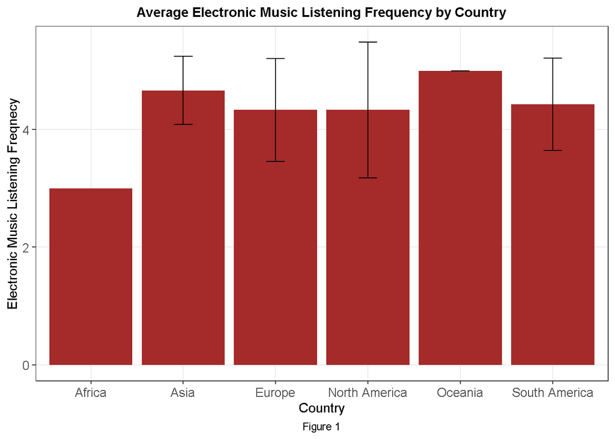

```r
library(ggplot2)
y |>
summarize(
    mfreq = mean(elec_music_listeningfreq),
    lfreq = mean(elec_music_listeningfreq) - sd(elec_music_listeningfreq),
    ufreq = mean(elec_music_listeningfreq) + sd(elec_music_listeningfreq),
    .by = Country
  ) |>
  ggplot(aes(x = Country, y = mfreq, ymin = lfreq, ymax = ufreq, fill=as.factor(Country))) +
  geom_bar(stat = "identity", fill = "brown") +
  geom_errorbar(width = 0.2)  +
  labs(x="Country",
       y="Electronic Music Listening Freqnecy",
       title = "Average Electronic Music Listening Frequency by Country",
       caption = "Figure 1") +
  theme_bw()+
    theme(
    plot.title = element_text(face = "bold", hjust = 0.5, size = 11),
    plot.caption = element_text(hjust = 0.5),
    panel.grid.minor = element_blank(),
    axis.text = element_text(size = 10),
    legend.position = "none")
```

*Figure 2:* I wanted to depict gender differences in music familiarity and check if they may be influenced by whether or not individuals received any formal musical training (beyond school). For that, I plotted the visual using aesthetic mappings as Gender on x-axis, music familiarity scores on y-axis, and filling by formal musical training variable. I used the boxplot geom, and facetgrid argument to depict the differences side by side, and lastly polished the figures using labs and theme arguments.

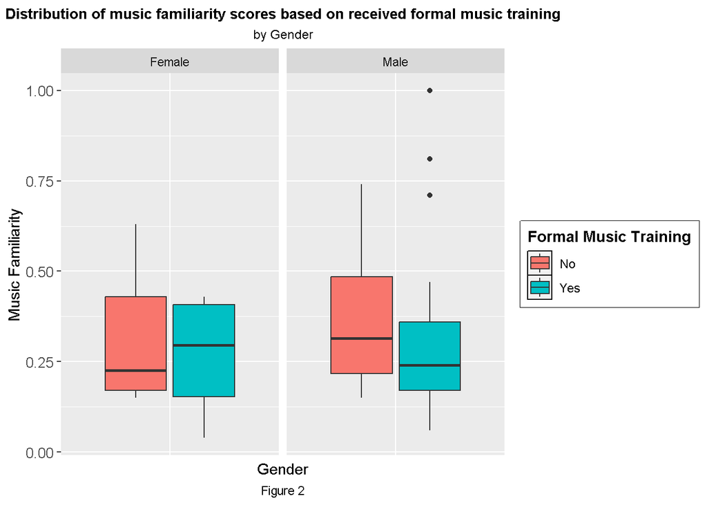

```r
ggplot(y, aes(x = Gender, y = Familiarity_score , fill = fl_music_training)) +
  geom_boxplot() +
  facet_grid(. ~ Gender, scales = "free") +
   labs(x = "Gender", y = "Music Familiarity",
        title = "Distribution of music familiarity scores based on received formal music training",
        subtitle = "by Gender",
       caption = "Figure 2") +
  scale_fill_discrete(name = "Formal Music Training") +
  theme_grey() +
    theme(
    axis.ticks.x = element_blank(),
    axis.text.x = element_blank(),
    plot.title = element_text(face = "bold", hjust = 0.5, size = 10),
  plot.subtitle = element_text(size = 9, hjust = 0.5),
    plot.caption = element_text(hjust = 0.5),
  legend.box.background = element_rect(color="black", linewidth=0.5),
        legend.key = element_rect(colour = "black"),
        legend.title = element_text(face = "bold"),
        axis.text = element_text(size = 10))
```

*Figure 3:* I wanted to depict the relationship between engagement with music and music familiarity scores based on participant’s highest educational degree. For that, I plotted the visual using aesthetic mappings as enagement with music on x-axis, music familiarity scores on y-axis. I used the point geom, regression line parameter, and facetwrap argument to depict the associations altogether within 1 plot, and lastly polished the figures using labs and theme arguments.

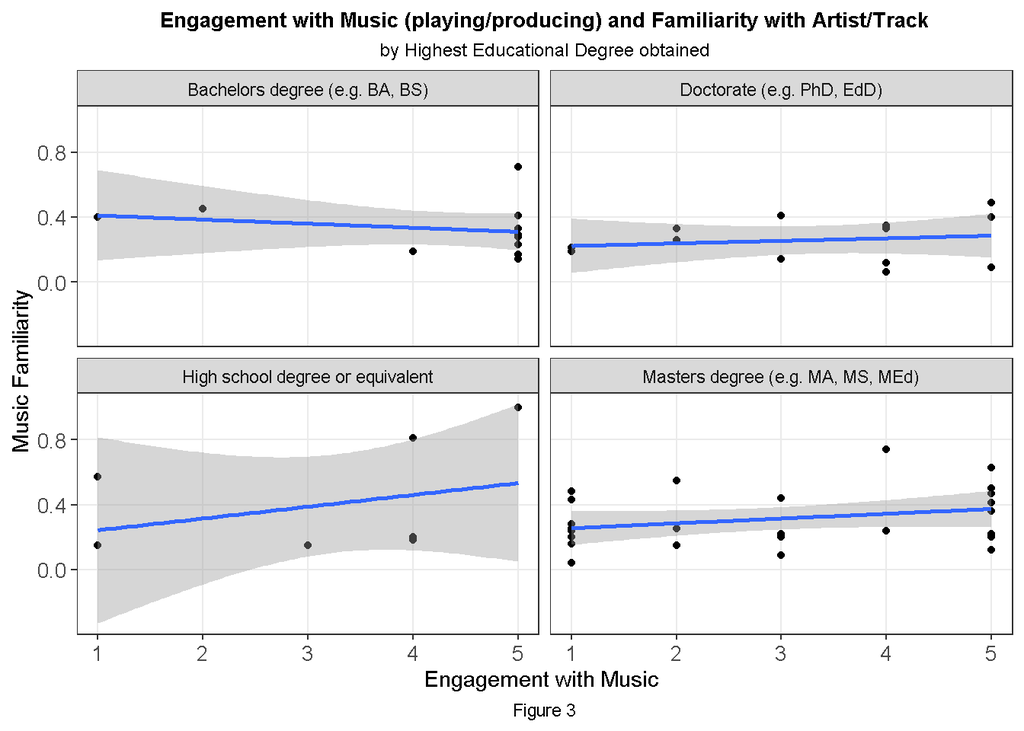

```r
ggplot(y, aes(x = eng_with_music, y = Familiarity_score)) +
  geom_point() +
  geom_smooth(method = "lm") +
  facet_wrap(~ as.factor(Highest_degree_re)) +
  labs(x = "Engagement with Music ", y = "Music Familiarity",
       title = "Engagement with Music (playing/producing) and Familiarity with Artist/Track",
       subtitle = "by Highest Educational Degree obtained",
       caption = "Figure 3") +
  theme_bw() +
theme(
  panel.grid.minor = element_blank(),
  plot.title = element_text(face = "bold", hjust = 0.5, size = 10),
  plot.subtitle = element_text(size = 9, hjust = 0.5),
  plot.caption = element_text(hjust = 0.5),
  axis.text = element_text(size = 10))
```

## Summary Tibbles

1.

```r
m <-
  y |>
  mutate(averageAge = (minAge + maxAge) / 2) |>
  summarize(
    total_participants = n_distinct(ID),
    averageAge = mean(averageAge),
    avg_Familiarity_scores = mean(Familiarity_score),
    .by = Gender
  ) |>
  print()
```

```
# A tibble: 2 × 4
  Gender total_participants averageAge avg_Familiarity_scores
  <fct>               <int>      <dbl>                  <dbl>
1 Male                   49       33.3                  0.321
2 Female                 10       35.5                  0.294
```

2.

```r
k <-
  y |>
  summarize(
    total_n = n_distinct(ID),
    avg_varied_music_taste = mean(Music_taste_varied),
    avg_elec_freq = mean(elec_music_listeningfreq),
    .by = Country
  ) |>
  print()
```

```
# A tibble: 6 × 4
  Country       total_n avg_varied_music_taste avg_elec_freq
  <chr>           <int>                  <dbl>         <dbl>
1 South America       7                   4.43          4.43
2 Europe             42                   4.33          4.33
3 North America       3                   4.33          4.33
4 Oceania             3                   4.33          5
5 Africa              1                   5             3
6 Asia                3                   4.33          4.67
```

## Conclusions

*Figure 1*

On average, people from the geographical region of Oceania, followed by the region of Asia, often listen to electronic music. Additionally, the geographical region with least electronic music listening frequency, on average, is Africa.

*Note:* these results should be interpreted with caution as from the summary tibble 2. we can see that each country except Europe has minimal observations.

*Figure 3*

Engagement with music increases as the music familiarity increases for individuals with a degree of high school (or equivalent). The association between engagement with music and music familiarity remains relatively stable/non-linear for individuals with Bachelors, Masters, and Doctorate degrees.

## Retrospective Report

Real-world datasets are large, unorganized, have inconsistent data types, and contain missing values or outliers. Cleaning and preparing this data for analysis can be challenging and requires knowledge of various data wrangling techniques.

In contrast, examples from class are usually cleaned and carefully curated to teach specific concepts. Instructors select examples that are more directly focused and easy to work with, so students can focus on learning the underlying principles, tools, and concepts. These examples are typically pre-processed and cleaned before analysis, which is not the case for real-world data.

Collecting own data requires to firstly have domain-specific knowledge, then if picking datasets online it is important to retrieve it from correct/accurate sources. Working with this data further involves overcoming various challenges related to data quality, data wrangling, analysis techniques, and effective data visualization. Specifically, the challenges that came up were:

- Handling missing data appropriately
- The number of observations were not helpful for drawing relatively accurate interpretations and conclusions
- Identifying suitable analysis methods and selecting appropriate visualizations to effectively communicate insights from the data based on objectives
- Presenting multiple variables or relationships in a clear and concise manner required thoughtful design choices